# Data Visualization: `ggplot` part 3

## Learning Goals

*At the end of this exercise, you will be able to:*  
1. Adjust the aesthetics of plots in ggplot using `themes`, `RColorBrewer`, and `paletteer.`  
2. Use faceting to produce multi-panel plots.

## Resources

- [ggplot2 cheatsheet](https://www.rstudio.com/wp-content/uploads/2015/03/ggplot2-cheatsheet.pdf)
- [R for Data Science](https://r4ds.had.co.nz/)
- [R Cookbook](http://www.cookbook-r.com/)
- [`ggplot` themes](https://ggplot2.tidyverse.org/reference/ggtheme.html)
- [Rebecca Barter `ggplot` Tutorial](http://www.rebeccabarter.com/blog/2017-11-17-ggplot2_tutorial/)
- [R Color Brewer](http://colorbrewer2.org/#type=sequential&scheme=BuGn&n=3)

## Load the libraries

```r
library(tidyverse)
library(RColorBrewer)
library(paletteer)
library(janitor)
```

```r
options(scipen=999) #cancels the use of scientific notation for the session
```

## Data

For this tutorial, we will use:  
[Homerange](http://datadryad.org/resource/doi:10.5061/dryad.q5j65/1). The data are from: Tamburello N, Cote IM, Dulvy NK (2015) Energy and the scaling of animal space use. The American Naturalist 186(2):196-211. http://dx.doi.org/10.1086/682070.

```r
homerange <- read_csv("data/Tamburelloetal_HomeRangeDatabase.csv", na = c("", "NA", "\\"))
```

## ggplot themes

There are many options to change the theme of your plots within ggplot. Have a look [here]https://ggplot2.tidyverse.org/reference/ggtheme.html) for a list of the themes.

Let’s start by building a simple barplot.

```r
p <- homerange %>%
  ggplot(aes(x=taxon, fill=trophic.guild))+
  geom_bar(na.rm=T, position="dodge")
```

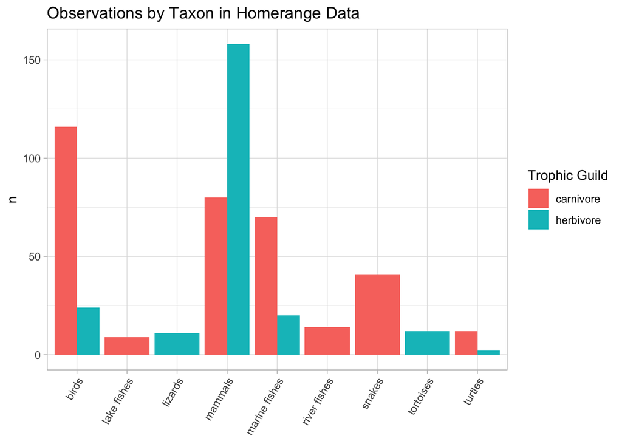

```r
p + theme_light()+
  theme(axis.text.x = element_text(angle = 60, hjust=1))+
  labs(title = "Observations by Taxon in Homerange Data",
       x = NULL,
       y= "n",
       fill= "Trophic Guild")
```

## Practice

1. Build a scatterplot that compares `log10.mass` and `log10.preymass`. Color the points by `taxon`. Store this plot as object `q`.

```r
q <- homerange %>%
  ggplot(aes(x = log10.mass, y = log10.preymass, color = taxon)) + geom_point()
```

2. Use plot `q` but add the classic theme.

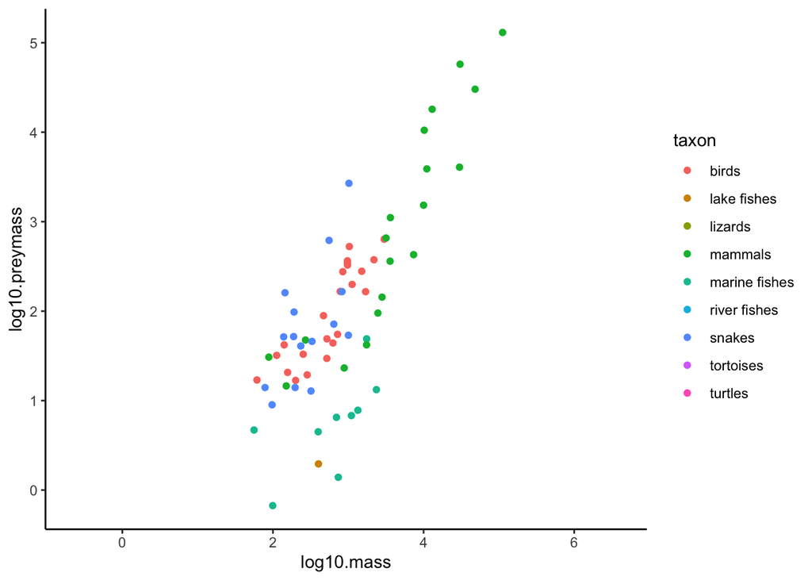

```r
q + theme_classic()
```

## Legends

There are lots of options to manipulate legends. Have a look [here](http://www.sthda.com/english/wiki/ggplot2-legend-easy-steps-to-change-the-position-and-the-appearance-of-a-graph-legend-in-r-software).

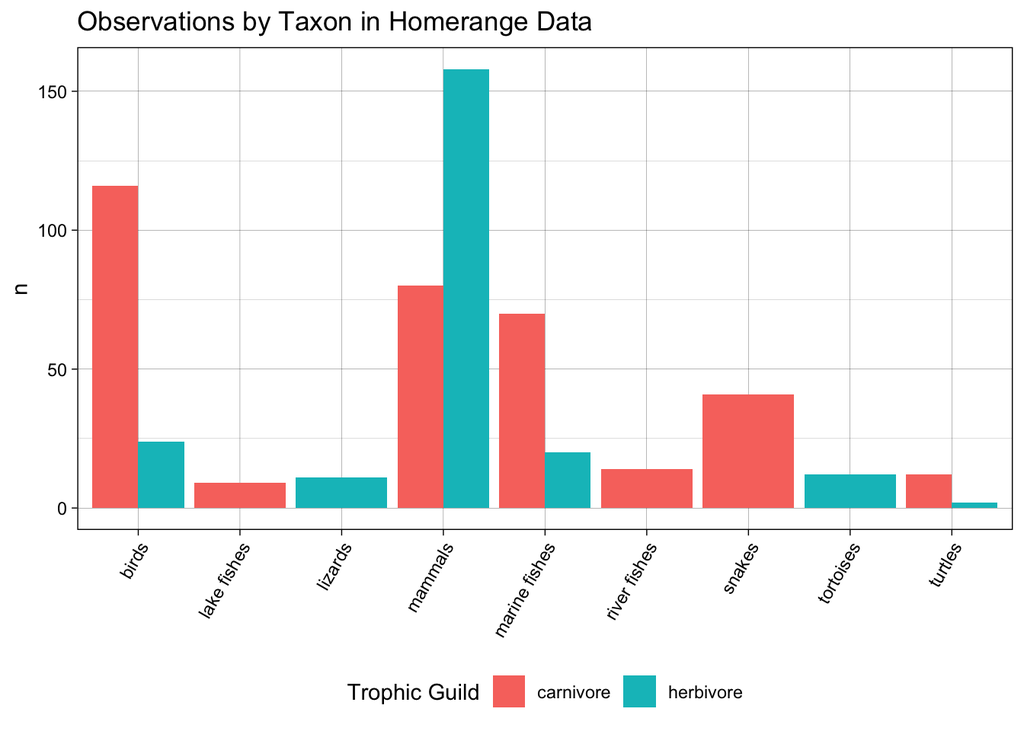

```r
p+theme_linedraw()+
  theme(legend.position = "bottom",
        axis.text.x = element_text(angle = 60, hjust=1))+
  labs(title = "Observations by Taxon in Homerange Data",
       x = NULL,
       y= "n",
       fill= "Trophic Guild")
```

## Not enough? Try using `ggthemes`

There are many packages that include additional themes, one of which is [ggthemes](https://yutannihilation.github.io/allYourFigureAreBelongToUs/). Some of these are nice because they are designed to mimic the look of popular publications.

```r
#install.packages("ggthemes")
library(ggthemes)
```

Here is a list of the `ggthemes`

```r
#ls("package:ggthemes")[grepl("theme_", ls("package:ggthemes"))]
```

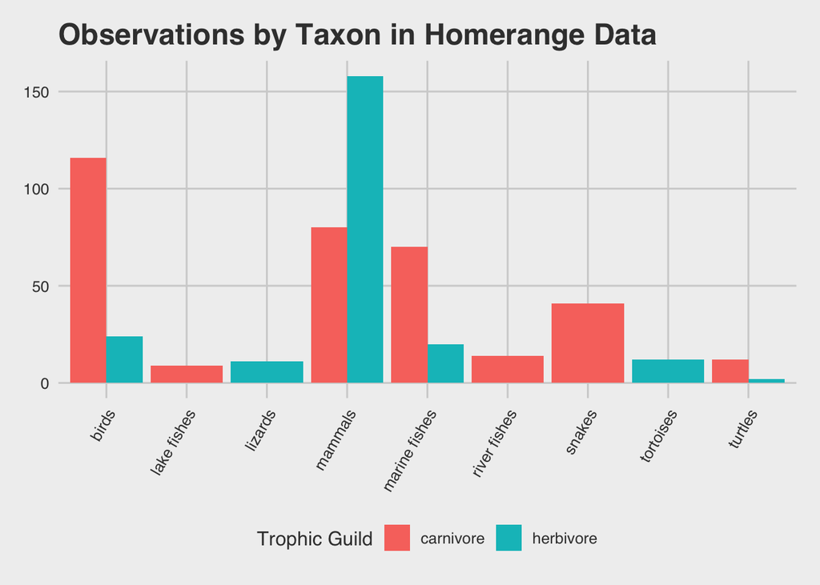

```r
p +
  theme_fivethirtyeight()+
  theme(legend.position = "bottom",
        axis.text.x = element_text(angle = 60, hjust=1))+
  labs(title = "Observations by Taxon in Homerange Data",
       x = NULL, #removes label from x axis
       y= "n",
       fill= "Trophic Guild")
```

## Practice

1. Use plot `q` and try the `theme_economist()` theme.

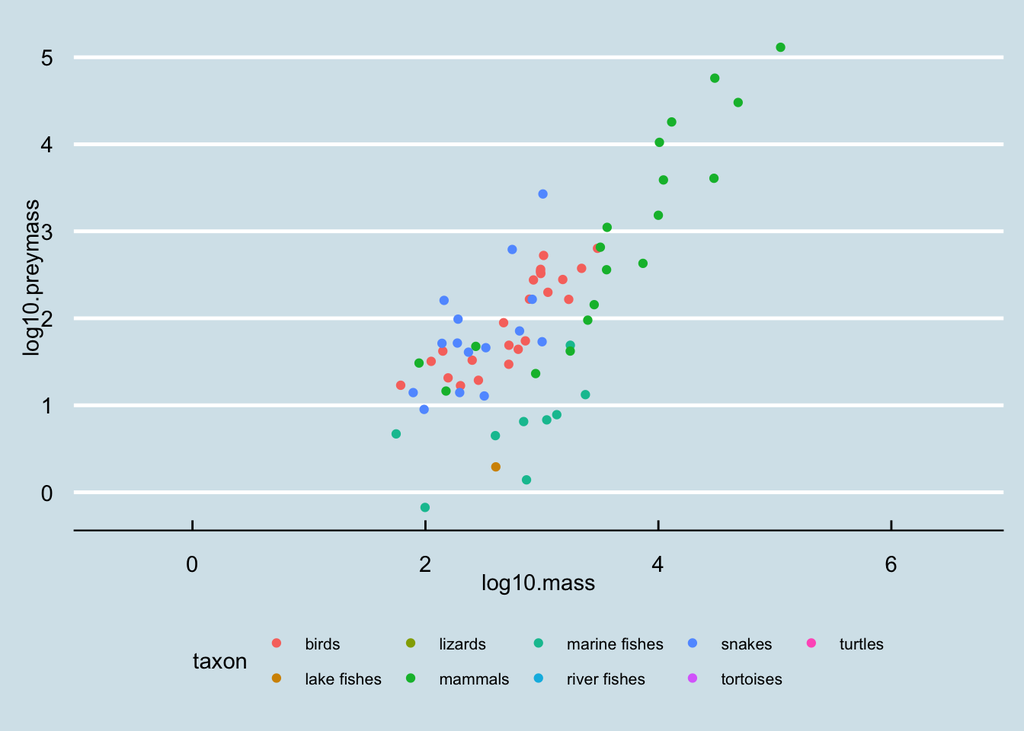

```r
q + theme_economist() + theme(legend.position = "bottom", legend.text = element_text(size = 8))
```

## RColorBrewer

The default colors used by ggplot are often uninspiring. They don’t make plots pop out in presentations or publications, and you may want to use a customized palette to make things visually consistent.

Access the help for `RColorBrewer`.

```r
?RColorBrewer
```

The thing to notice is that there are three different color palettes: 1) sequential, 2) diverging, and 3) qualitative. Within each of these there are several selections. You can bring up the colors by using `display.brewer.pal()`. Specify the number of colors that you want and the palette name.

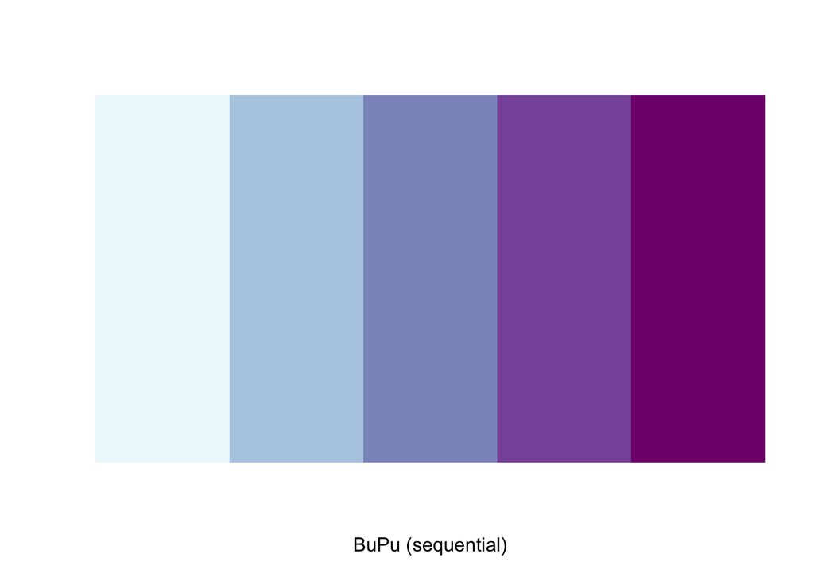

```r
display.brewer.pal(5,"BuPu") #sequential palette
```

The [R Color Brewer](http://colorbrewer2.org/#type=sequential&scheme=BuGn&n=3) website is very helpful for getting an idea of the color palettes. To make things easy, use these two guidelines:

+`scale_colour_brewer()` is for points  
+`scale_fill_brewer()` is for fills

Here I chose the `Paired` palette. Take a moment and experiment with other options.

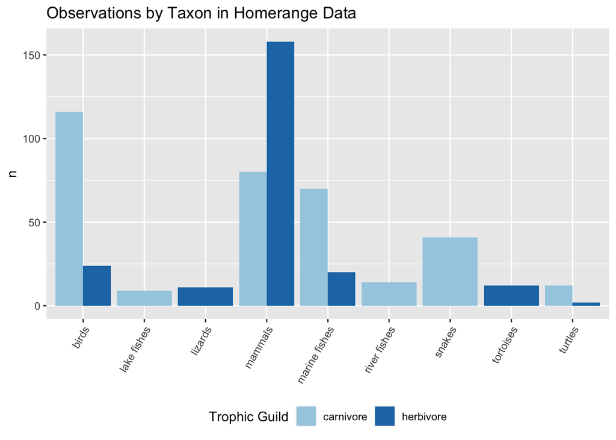

```r
p+scale_fill_brewer(palette = "Paired")+
  theme(legend.position = "bottom",
        axis.text.x = element_text(angle = 60, hjust=1))+
  labs(title = "Observations by Taxon in Homerange Data",
       x = NULL,
       y= "n",
       fill= "Trophic Guild")
```

## Practice

1. Keep using the `same`q` plot, but test out one of R Color Brewer palettes.

[figure not shown]

```r
q + scale_color_brewer(palette = "BuPuGn")
```

## Manually Setting Colors

You can also use `paleteer` to build a custom palette for consistency. To access the `paleteer` collection, I add it to a new object.

```r
colors <- paletteer::palettes_d_names
colors
```

```
## # A tibble: 2,415 × 5
##    package   palette   length type        novelty
##    <chr>     <chr>      <int> <chr>       <lgl>
##  1 awtools   a_palette      8 sequential  TRUE
##  2 awtools   ppalette       8 qualitative TRUE
##  3 awtools   bpalette      16 qualitative TRUE
##  4 awtools   gpalette       4 sequential  TRUE
##  5 awtools   mpalette       9 qualitative TRUE
##  6 awtools   spalette       6 qualitative TRUE
##  7 basetheme brutal        10 qualitative TRUE
##  8 basetheme clean         10 qualitative TRUE
##  9 basetheme dark          10 qualitative TRUE
## 10 basetheme deepblue      10 qualitative TRUE
## # ℹ 2,405 more rows
```

Now we can display the palettes. Assign the palette to `my_palette` and then build this base R bar plot. There are a lot of options; `paleteer` is a collection of popular palettes. I really like the [`ggsci` package] (https://cran.r-project.org/web/packages/ggsci/vignettes/ggsci.html)

```r
my_palette <- paletteer_d("LaCroixColoR::paired") #store your palette
```

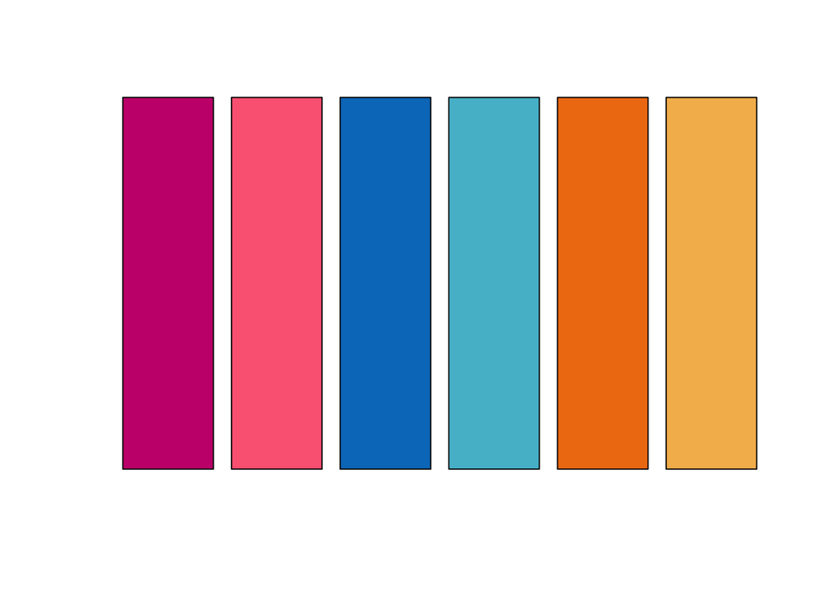

```r
barplot(rep(1,6), axes=FALSE, col=my_palette) #show your palette
```

Now we just identify `my_palette` as part of `scale_fill_manual()`

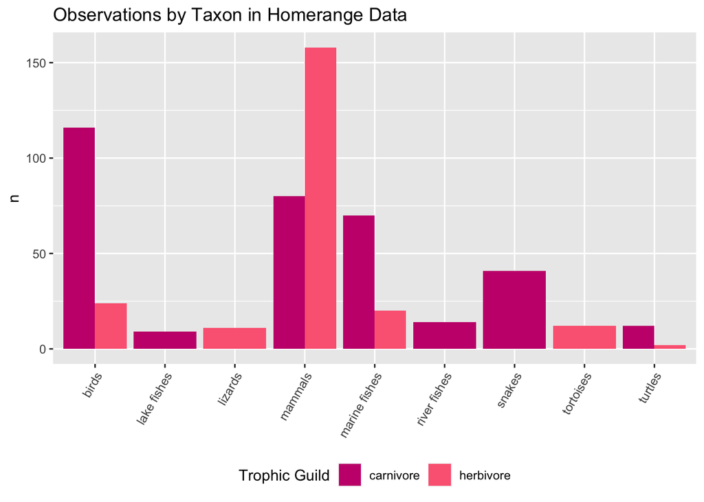

```r
p+scale_fill_manual(values=my_palette)+
  theme(legend.position = "bottom",
        axis.text.x = element_text(angle = 60, hjust=1))+
  labs(title = "Observations by Taxon in Homerange Data",
       x = NULL,
       y= "n",
       fill= "Trophic Guild")
```

## Practice

1. Keep using the `same`q`plot, but test out one of`paleteer` themes.

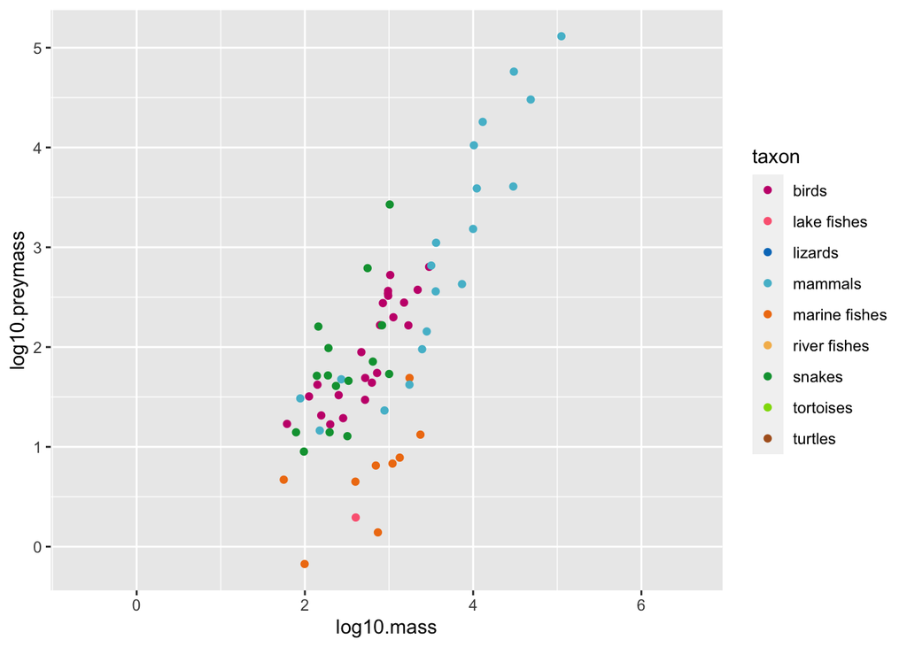

```r
q + scale_color_manual(values = my_palette)
```

## Faceting

[Faceting](https://ggplot2-book.org/facet.html) is one of the amazing features of ggplot. It allows us to make multi-panel plots for easy comparison. Here is a boxplot that shows the range of log10.mass by taxon.

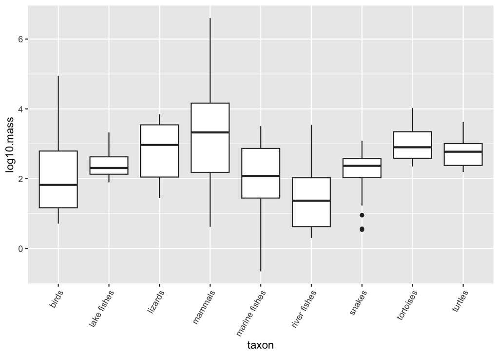

```r
homerange %>%
  ggplot(aes(x=taxon, y=log10.mass))+
  geom_boxplot()+
  theme(axis.text.x = element_text(angle = 60, hjust=1))
```

There are other categorical variables that might be interesting to overlay. `facet_wrap()` makes a ribbon of panels by a specified categorical variable and allows you to control how you want them arranged.

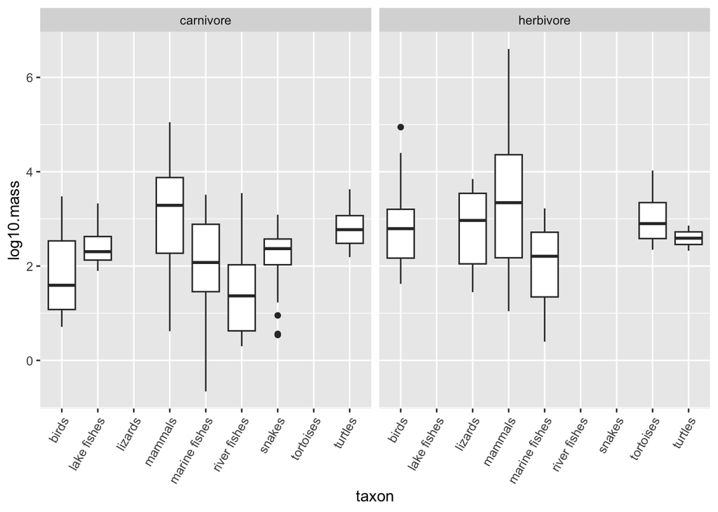

```r
homerange %>%
  ggplot(aes(x=taxon, y=log10.mass))+
  geom_boxplot()+
  theme(axis.text.x = element_text(angle = 60, hjust=1)) + facet_wrap(~trophic.guild)
```

`facet_grid()` allows control over the faceted variable; it can be arranged in rows or columns. rows~columns.

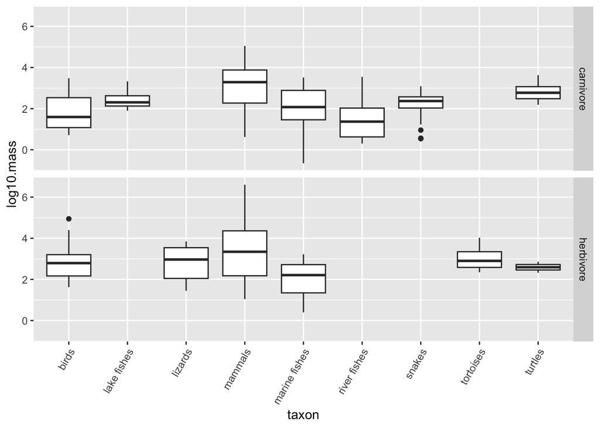

```r
homerange %>%
  ggplot(aes(x=taxon, y=log10.mass))+
  geom_boxplot()+
  theme(axis.text.x = element_text(angle = 60, hjust=1)) + facet_grid(trophic.guild ~.) #flip ~. to beginning for same display as facet_wrap
```

`facet_grid()` will also allow the comparison of two categorical variables, just remember a~b where a is rows and b is columns.

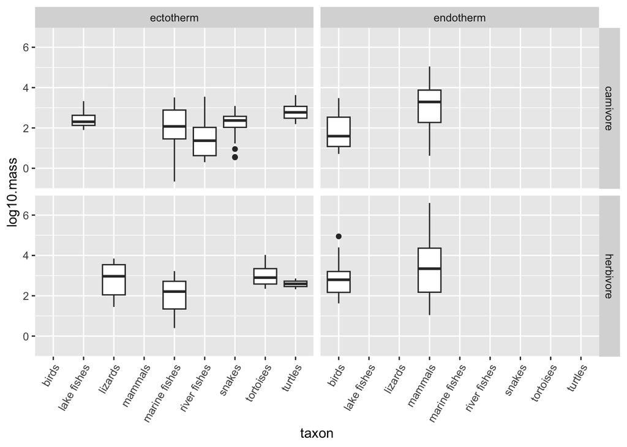

```r
homerange %>%
  ggplot(aes(x=taxon, y=log10.mass))+
  geom_boxplot()+
  theme(axis.text.x = element_text(angle = 60, hjust=1)) + facet_grid(trophic.guild ~ thermoregulation)
```

## Practice

1. Use facet_wrap to compare the distribution of `log10.mass` by `thermoregulation`.
2. Use facet_grid to compare the distribution of `log10.mass` by `locomotion`.

## Wrap-up

Please review the learning goals and be sure to use the code here as a reference when completing the homework.  
–>[Home](https://jmledford3115.github.io/datascibiol/)